# Barton Springs Salamander Data Analysis Project

## Star this project!

[figure not shown]

## Project Description

This data science project investigates the relationship between water quality parameters and the population sizes of Barton Springs Salamanders in Austin, Texas. Barton Springs Salamanders are a vulnerable species, and understanding how water quality affects their population is crucial for ecological preservation. This project utilizes a dataset obtained from the [Austin Open Data Portal](http://data.austintexas.gov) to conduct a comprehensive analysis.

## Table of Contents:

- **Visualizations and Modeling Code**
  - DissolvedOxygenvsSalamander.Rmd
  - PH.Rmd
  - SiteVsSalamander.Rmd
  - TimeVsSalamander.Rmd
  - DissolvedOxygenOverTime.Rmd
  - FlowType.Rmd

  *For pdf layouts:*
  - visualizations code pdf (Folder)

  *For html layouts:*
  - DissolvedOxygenvsSalamander.html
  - PH.html
  - SiteVsSalamander.html
  - TimeVsSalamander.html
  - DissolvedOxygenOverTime.html
  - FlowType.html
- **Website:**
  - index.html

  *Images for the Website:*
  - salamander.png
  - scatter_plot_regression_line.png
  - salamander_regression_plot.png -AvgSalPOxy.png
  - avatar.jpg
  - OxyVsTime.png
  - AvgSalOxygen.png
  - PolynomialRegression.png -SalVsTime.png
  - AvgFlowVsSal.png
- **Data:**
  - Barton_Springs_Salamanders_DO_and_Flow.csv
  - CopyOfBarton_Springs_Salamanders_DO_and_Flow.csv
  - DATA.xlsx
  - Average Dissolved Oxygen Per Year.xlsx
  - PH.xlsx

## Goals

The primary goals of this project are as follows: 1. Analyze the relationship between Dissolved Oxygen (DO) levels and the population of Barton Springs Salamanders. 2. Investigate the impact of flow rates on the salamander population. 3. Contribute to informed decision-making for ecological protection and restoration efforts in Barton Springs.

## Data Source

The dataset used for this analysis is titled “Barton Springs Salamanders - DO and Flow” and can be accessed through the [Austin Open Data Portal](https://data.austintexas.gov/Environment/Barton-Springs-Salamanders-DO-and-Flow/pyic-v8yf). The dataset contains approximately 40,000 data points with eight columns, including: - Watershed location - Date and time of data collection - Site name - Longitude and latitude coordinates - Site type (e.g., spring) - Medium (e.g., groundwater, benthic) - Parameter (e.g., dissolved oxygen, salamander size)

## Hypotheses

This project explores the following hypotheses:

1. **Hypothesis 1:** Increased levels of Dissolved Oxygen (DO) in a Barton spring will lead to a larger population of salamanders.
- Null Hypothesis: There is no significant relationship between DO levels and salamander population size.
2. **Hypothesis 2:** Higher flow rates will result in a smaller population of salamanders.
- Null Hypothesis: There is no significant relationship between flow rates and salamander population size.

## Plots

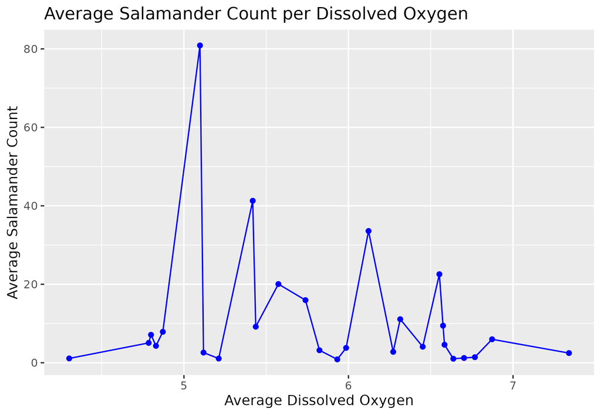

Visualization #1

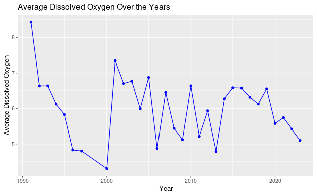

Visualization #2

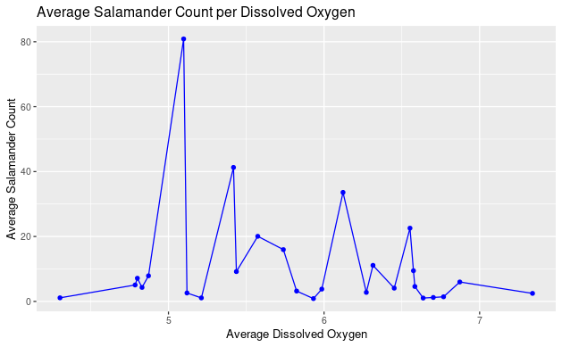

Visualization #3

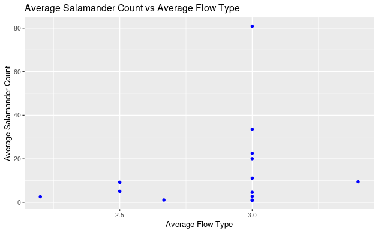

Visualization #4

## References

- [Austin Open Data Portal](http://data.austintexas.gov)
- Dataset Source: [Barton Springs Salamanders - DO and Flow](https://data.austintexas.gov/Environment/Barton-Springs-Salamanders-DO-and-Flow/pyic-v8yf)

## Modeling:

The best regression we had:

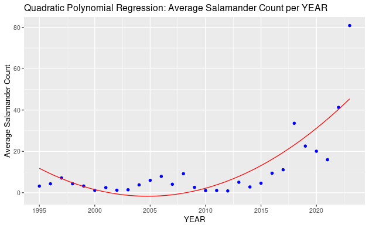

Model #1

## Support the Project

If you find this project helpful and would like to support its development, consider making a donation:

[figure not shown]

Your contributions help us maintain and improve Barton Springs. Thank you for your support!